# Q & K Box 15.3

We described the study by Lemmens et al. (2015) who sampled various biotic communities in artificial ponds in Belgium that were classified into one of four management types in Box 15.2. In addition to the biotic sampling, they recorded 15 environmental variables (e.g. depth, salinity, pH etc.) for each pond and covers of submerged, floating, and emergent vegetation. They used RDA to comprehensively examine the patterns in the various biotic communities (ordination) constrained by either management variables, drainage strategy, environmental variables, or the fish community. We will focus on the macroinvertebrate community (abundances of families) and do two RDAs, one constrained by the four management categories and a second constrained by the continuous environmental variables; we did not include management type with the environmental variables in one analysis as some of the predictors varied with management type (i.e. collinearity). We will use a covariance matrix for the invertebrate data and a Hellinger transformation that converts raw abundances to proportional abundances. This provides a comparison to the CCA we will do as a second analysis below.

The paper is [here](https://doi.org/10.1371/journal.pone.0139371) and the pond subset for this example is lemminvert2.csv and we also use the environmental variables lemmenv.csv

Lemmens, P., Mergeay, J., Van Wichelen, J., De Meester, L. & Declerck, S. A. (2015). The impact of conservation management on the community composition of multiple organism groups in eutrophic interconnected man-made ponds. *PLoS One*, 10, e0139371.

### Preliminaries

Load required packages (vegan) plus tidyverse, etc

```r
# packages: vegan, car
source("../R/libraries.R")
library(vegan)
```

Read in data files

```r
lemminvert <- read_csv("../data/lemminvert2.csv")
lemmenv <- read_csv("../data/lemmenv.csv")
```

## Do RDA on management first

Set no management as reference Do Hellinger transformation

```r
lemmenv$manag <- factor(lemmenv$manag,levels=c("nm","nf","yf","li"))
lemminvert1 <- lemminvert[,-(1:3)]
lemminvert1h <- decostand(lemminvert1, method = "hellinger")
lemmens1.rda <- rda(lemminvert1h~manag, scale=FALSE, data=lemmenv)
summary(lemmens1.rda)
```

```
Call:
rda(formula = lemminvert1h ~ manag, data = lemmenv, scale = FALSE)

Partitioning of variance:
                 Inertia Proportion
Total         0.29764520   1.000000
Constrained   0.07746038   0.260244
Unconstrained 0.22018483   0.739756

Eigenvalues, and their contribution to the variance

Importance of components:
                            RDA1       RDA2        RDA3        PC1        PC2        PC3        PC4        PC5        PC6        PC7         PC8         PC9        PC10        PC11
Eigenvalue            0.04834204 0.02378647 0.005331859 0.05773624 0.04007458 0.03044115 0.02399770 0.01555144 0.01303226 0.01008716 0.007047255 0.005960197 0.004974072 0.003539032
Proportion Explained  0.16241499 0.07991553 0.017913474 0.19397671 0.13463875 0.10227329 0.08062518 0.05224826 0.04378454 0.03388988 0.023676695 0.020024504 0.016711412 0.011890102
Cumulative Proportion 0.16241499 0.24233052 0.260243992 0.45422070 0.58885945 0.69113274 0.77175792 0.82400618 0.86779072 0.90168060 0.925357295 0.945381799 0.962093211 0.973983313
                             PC12        PC13        PC14         PC15         PC16       PC17         PC18         PC19
Eigenvalue            0.002560003 0.001901488 0.001002660 0.0009101283 0.0007461774 0.00030008 0.0001744904 0.0001487147
Proportion Explained  0.008600855 0.006388438 0.003368641 0.0030577625 0.0025069357 0.00100818 0.0005862362 0.0004996375
Cumulative Proportion 0.982584168 0.988972607 0.992341248 0.9953990102 0.9979059459 0.99891413 0.9995003625 1.0000000000

Accumulated constrained eigenvalues
Importance of components:
                            RDA1       RDA2        RDA3
Eigenvalue            0.04834204 0.02378647 0.005331859
Proportion Explained  0.62408736 0.30707926 0.068833380
Cumulative Proportion 0.62408736 0.93116662 1.000000000

Scaling 2 for species and site scores
* Species are scaled proportional to eigenvalues
* Sites are unscaled: weighted dispersion equal on all dimensions
* General scaling constant of scores:  1.599669968


Species scores

            RDA1          RDA2          RDA3           PC1           PC2           PC3
ca  -0.042218357 -0.1890614607 -0.0398889939  0.0862415827  0.0325433453 -0.1658836456
ba   0.219522194  0.0780414669 -0.0026948860  0.2551936765  0.3938227222  0.0583275846
ac   0.044068201 -0.0403467076 -0.0310340826  0.0159159791  0.0256296462  0.0492706284
```

[output cut: 84 more lines]

```
Biplot scores for constraining variables

             RDA1       RDA2       RDA3 PC1 PC2 PC3
manag1 0.03267726 -0.9562533 0.29070906   0   0   0
manag2 0.89970361 -0.4327817 0.05686278   0   0   0
manag3 0.39536799 -0.1630427 0.90393652   0   0   0


Centroids for factor constraints

               RDA1        RDA2         RDA3 PC1 PC2 PC3
managnm -0.21805122 -0.45460012 -0.009868727   0   0   0
managnf  0.56902425 -0.02220176 -0.276131946   0   0   0
managyf  0.06455954  0.20249142  0.519674440   0   0   0
managli -0.34122400  0.41565223 -0.333661164   0   0   0
```

```r
RsquareAdj(lemmens1.rda)
```

```
$r.squared
[1] 0.2602439924

$adj.r.squared
[1] 0.1434404122
```

```r
coef(lemmens1.rda)
```

```
                 RDA1           RDA2            RDA3
manag1 -0.14792323866 -0.30627290057  0.009457027199
manag2  0.34410041797 -0.03596817252 -0.156991818312
manag3  0.02874492909  0.10449403919  0.340489788768
```

```r
anova.cca(lemmens1.rda, permutations=1000)
```

```
Permutation test for rda under reduced model
Permutation: free
Number of permutations: 1000

Model: rda(formula = lemminvert1h ~ manag, data = lemmenv, scale = FALSE)
         Df    Variance       F   Pr(>F)
Model     3 0.077460376 2.22805 0.003996 **
Residual 19 0.220184826
---
Signif. codes:  0 ‘***’ 0.001 ‘**’ 0.01 ‘*’ 0.05 ‘.’ 0.1 ‘ ’ 1
```

```r
anova.cca(lemmens1.rda, permutations=1000, by="margin")
```

```
Permutation test for rda under reduced model
Marginal effects of terms
Permutation: free
Number of permutations: 1000

Model: rda(formula = lemminvert1h ~ manag, data = lemmenv, scale = FALSE)
         Df    Variance       F   Pr(>F)
manag     3 0.077460376 2.22805 0.002997 **
Residual 19 0.220184826
---
Signif. codes:  0 ‘***’ 0.001 ‘**’ 0.01 ‘*’ 0.05 ‘.’ 0.1 ‘ ’ 1
```

```r
anova.cca(lemmens1.rda, permutations=1000, by="axis")
```

```
Permutation test for rda under reduced model
Forward tests for axes
Permutation: free
Number of permutations: 1000

Model: rda(formula = lemminvert1h ~ manag, data = lemmenv, scale = FALSE)
         Df    Variance       F   Pr(>F)
RDA1      1 0.048342041 4.17149 0.004995 **
RDA2      1 0.023786475 2.05256 0.098901 .
RDA3      1 0.005331859 0.46009 0.957043
Residual 19 0.220184826
---
Signif. codes:  0 ‘***’ 0.001 ‘**’ 0.01 ‘*’ 0.05 ‘.’ 0.1 ‘ ’ 1
```

Do triplot; category scaling type = 2 probably the best plots to display

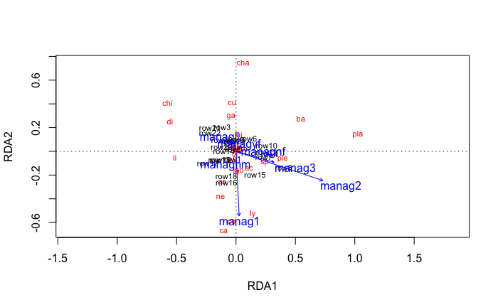

```r
ordiplot(lemmens1.rda,scaling=1,type="text")
```

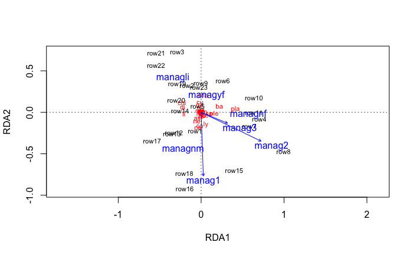

```r
ordiplot(lemmens1.rda,scaling=2,type="text")
```

## Do RDA on env variables

Preliminary look at scatterplot; look for variables with unusual distributions and check for correlations

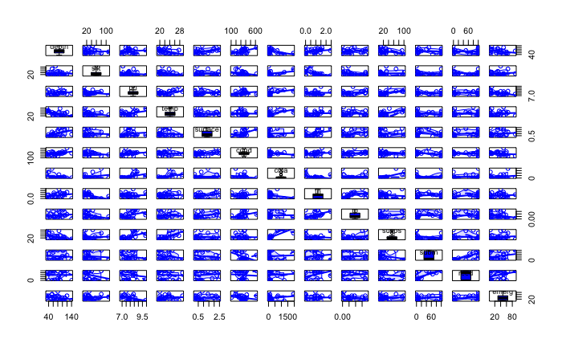

```r
scatterplotMatrix(~depth+silt+ph+temp+surface+cond+chla+tn+tp+susps+subm+reed+emerg,data=lemmenv,diagonal=list(method='boxplot'))
```

```r
cor(lemmenv[,c('depth','silt','ph','o2','temp','surface','trans','cond','chla','tn','tp','susps','subm','reed','emerg')])
```

```
                   depth            silt             ph             o2           temp        surface           trans            cond            chla             tn              tp
depth    1.0000000000000 -0.017616760461  0.13430650028 -0.27121523185 -0.47112653499  0.44942137904  0.264253776867  0.436551706608 -0.347611541276  0.23362402503  0.106097653875
silt    -0.0176167604607  1.000000000000 -0.17348171304 -0.17841277408 -0.25963499972 -0.04291205706  0.024811354455 -0.238480267142  0.250808793062 -0.47572668858 -0.314323812990
ph       0.1343065002808 -0.173481713042  1.00000000000  0.69636421850  0.34190093476  0.10830511855 -0.262039580615  0.170589213338  0.418416898246  0.03097470515  0.352357063644
o2      -0.2712152318545 -0.178412774082  0.69636421850  1.00000000000  0.59310269041  0.11258805864 -0.381857745485 -0.055885189668  0.532365462299  0.15752860554  0.118275090681
temp    -0.4711265349923 -0.259634999717  0.34190093476  0.59310269041  1.00000000000 -0.10252025899 -0.512112034212 -0.026694034703  0.439457016299  0.06453460843 -0.053945908244
surface  0.4494213790397 -0.042912057064  0.10830511855  0.11258805864 -0.10252025899  1.00000000000  0.114288567110  0.450017240377  0.054155717085  0.34550249931  0.271624362448
trans    0.2642537768666  0.024811354455 -0.26203958062 -0.38185774548 -0.51211203421  0.11428856711  1.000000000000  0.005469303119 -0.588751746901  0.20399197572  0.061584252994
cond     0.4365517066083 -0.238480267142  0.17058921334 -0.05588518967 -0.02669403470  0.45001724038  0.005469303119  1.000000000000 -0.190481924873  0.13957964040  0.306847862735
chla    -0.3476115412764  0.250808793062  0.41841689825  0.53236546230  0.43945701630  0.05415571708 -0.588751746901 -0.190481924873  1.000000000000 -0.27957165781  0.009360204518
tn       0.2336240250303 -0.475726688577  0.03097470515  0.15752860554  0.06453460843  0.34550249931  0.203991975724  0.139579640402 -0.279571657813  1.00000000000  0.500553919228
tp       0.1060976538753 -0.314323812990  0.35235706364  0.11827509068 -0.05394590824  0.27162436245  0.061584252994  0.306847862735  0.009360204518  0.50055391923  1.000000000000
susps   -0.3862440505484  0.009748267036  0.48986299063  0.57466492943  0.67849360517 -0.05300543834 -0.751549429641 -0.048437804756  0.782024207885 -0.11079257481  0.140758517363
subm    -0.0784175341518 -0.091227150419 -0.21175426468 -0.11745731349 -0.18746419839 -0.18724864572  0.191430935321 -0.394005804277  0.060139781123  0.15549644782  0.062217715215
reed     0.0006500370807 -0.277002133433 -0.14608695599  0.01560271693 -0.03402615003  0.11725585051  0.076445586444 -0.066476696670  0.066846774466  0.34219123738  0.114074475863
emerg   -0.2424572860053  0.105829333082 -0.38656803058 -0.09980845727  0.09539126577  0.08875116750 -0.108264276403 -0.205514809634  0.173774308694  0.06346373809 -0.285908967371
                  susps           subm             reed          emerg
depth   -0.386244050548 -0.07841753415  0.0006500370807 -0.24245728601
silt     0.009748267036 -0.09122715042 -0.2770021334331  0.10582933308
ph       0.489862990629 -0.21175426468 -0.1460869559873 -0.38656803058
o2       0.574664929431 -0.11745731349  0.0156027169307 -0.09980845727
temp     0.678493605174 -0.18746419839 -0.0340261500303  0.09539126577
surface -0.053005438344 -0.18724864572  0.1172558505087  0.08875116750
trans   -0.751549429641  0.19143093532  0.0764455864441 -0.10826427640
cond    -0.048437804756 -0.39400580428 -0.0664766966696 -0.20551480963
chla     0.782024207885  0.06013978112  0.0668467744656  0.17377430869
tn      -0.110792574812  0.15549644782  0.3421912373808  0.06346373809
tp       0.140758517363  0.06221771522  0.1140744758629 -0.28590896737
susps    1.000000000000 -0.28599187142 -0.1330961940857  0.07991696144
subm    -0.285991871423  1.00000000000  0.7316333379287  0.20746707245
reed    -0.133096194086  0.73163333793  1.0000000000000  0.27856872790
emerg    0.079916961444  0.20746707245  0.2785687278980  1.00000000000
```

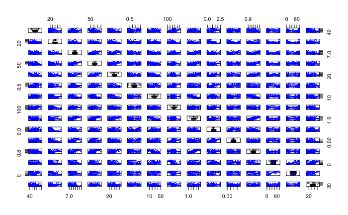

```r
# transform chla and susps
lemmenv$lchla <- log10(lemmenv$chla)
lemmenv$lsusps <- log10(lemmenv$susps)
scatterplotMatrix(~depth+silt+ph+o2+temp+surface+trans+cond+lchla+tn+tp+lsusps+subm+reed+emerg,data=lemmenv,diagonal=list(method='boxplot'))
```

```r
cor(lemmenv[,c('depth','silt','ph','o2','temp','surface','trans','cond','lchla','tn','tp','lsusps','subm','reed','emerg')])
```

```
                   depth           silt             ph             o2           temp        surface           trans            cond           lchla             tn             tp
depth    1.0000000000000 -0.01761676046  0.13430650028 -0.27121523185 -0.47112653499  0.44942137904  0.264253776867  0.436551706608 -0.250339753145  0.23362402503  0.10609765388
silt    -0.0176167604607  1.00000000000 -0.17348171304 -0.17841277408 -0.25963499972 -0.04291205706  0.024811354455 -0.238480267142 -0.115500652408 -0.47572668858 -0.31432381299
ph       0.1343065002808 -0.17348171304  1.00000000000  0.69636421850  0.34190093476  0.10830511855 -0.262039580615  0.170589213338  0.429453499027  0.03097470515  0.35235706364
o2      -0.2712152318545 -0.17841277408  0.69636421850  1.00000000000  0.59310269041  0.11258805864 -0.381857745485 -0.055885189668  0.520567397541  0.15752860554  0.11827509068
temp    -0.4711265349923 -0.25963499972  0.34190093476  0.59310269041  1.00000000000 -0.10252025899 -0.512112034212 -0.026694034703  0.571308038750  0.06453460843 -0.05394590824
surface  0.4494213790397 -0.04291205706  0.10830511855  0.11258805864 -0.10252025899  1.00000000000  0.114288567110  0.450017240377 -0.047841498152  0.34550249931  0.27162436245
trans    0.2642537768666  0.02481135446 -0.26203958062 -0.38185774548 -0.51211203421  0.11428856711  1.000000000000  0.005469303119 -0.782615681927  0.20399197572  0.06158425299
cond     0.4365517066083 -0.23848026714  0.17058921334 -0.05588518967 -0.02669403470  0.45001724038  0.005469303119  1.000000000000 -0.167905947561  0.13957964040  0.30684786274
lchla   -0.2503397531454 -0.11550065241  0.42945349903  0.52056739754  0.57130803875 -0.04784149815 -0.782615681927 -0.167905947561  1.000000000000 -0.16572488776  0.06844173512
tn       0.2336240250303 -0.47572668858  0.03097470515  0.15752860554  0.06453460843  0.34550249931  0.203991975724  0.139579640402 -0.165724887761  1.00000000000  0.50055391923
tp       0.1060976538753 -0.31432381299  0.35235706364  0.11827509068 -0.05394590824  0.27162436245  0.061584252994  0.306847862735  0.068441735122  0.50055391923  1.00000000000
lsusps  -0.3302692268658  0.01952331251  0.39782646577  0.52545125907  0.67369835084 -0.14207718016 -0.754240584318 -0.082873919777  0.879064890447 -0.09724699645  0.08021720445
subm    -0.0784175341518 -0.09122715042 -0.21175426468 -0.11745731349 -0.18746419839 -0.18724864572  0.191430935321 -0.394005804277 -0.028987516710  0.15549644782  0.06221771522
reed     0.0006500370807 -0.27700213343 -0.14608695599  0.01560271693 -0.03402615003  0.11725585051  0.076445586444 -0.066476696670  0.007427848248  0.34219123738  0.11407447586
emerg   -0.2424572860053  0.10582933308 -0.38656803058 -0.09980845727  0.09539126577  0.08875116750 -0.108264276403 -0.205514809634  0.078136797535  0.06346373809 -0.28590896737
                lsusps           subm             reed          emerg
depth   -0.33026922687 -0.07841753415  0.0006500370807 -0.24245728601
silt     0.01952331251 -0.09122715042 -0.2770021334331  0.10582933308
ph       0.39782646577 -0.21175426468 -0.1460869559873 -0.38656803058
o2       0.52545125907 -0.11745731349  0.0156027169307 -0.09980845727
temp     0.67369835084 -0.18746419839 -0.0340261500303  0.09539126577
surface -0.14207718016 -0.18724864572  0.1172558505087  0.08875116750
trans   -0.75424058432  0.19143093532  0.0764455864441 -0.10826427640
cond    -0.08287391978 -0.39400580428 -0.0664766966696 -0.20551480963
lchla    0.87906489045 -0.02898751671  0.0074278482481  0.07813679754
tn      -0.09724699645  0.15549644782  0.3421912373808  0.06346373809
tp       0.08021720445  0.06221771522  0.1140744758629 -0.28590896737
lsusps   1.00000000000 -0.25143199023 -0.1569631837490  0.08786419690
subm    -0.25143199023  1.00000000000  0.7316333379287  0.20746707245
reed    -0.15696318375  0.73163333793  1.0000000000000  0.27856872790
emerg    0.08786419690  0.20746707245  0.2785687278980  1.00000000000
```

```r
# exclude o2, trans, susps and subm
# standardize remaining env variables
lemmenv$depth <- scale(lemmenv$depth)
lemmenv$silt <- scale(lemmenv$silt)
lemmenv$ph <- scale(lemmenv$ph)
lemmenv$temp <- scale(lemmenv$temp)
lemmenv$surface <- scale(lemmenv$surface)
lemmenv$cond <- scale(lemmenv$cond)
lemmenv$clhla <- scale(lemmenv$lchla)
lemmenv$tn <- scale(lemmenv$tn)
lemmenv$tp <- scale(lemmenv$tp)
lemmenv$reed <- scale(lemmenv$reed)
lemmenv$emerg <- scale(lemmenv$emerg)
```

### Now do RDA

```r
lemmens2.rda <- rda(lemminvert1h~depth+silt+ph+temp+surface+cond+lchla+tn+tp+reed+emerg, scale=FALSE, data=lemmenv)
summary(lemmens2.rda)
```

```
Call:
rda(formula = lemminvert1h ~ depth + silt + ph + temp + surface +      cond + lchla + tn + tp + reed + emerg, data = lemmenv, scale = FALSE)

Partitioning of variance:
                Inertia Proportion
Total         0.2976452  1.0000000
Constrained   0.1738784  0.5841801
Unconstrained 0.1237668  0.4158199

Eigenvalues, and their contribution to the variance

Importance of components:
                            RDA1       RDA2       RDA3       RDA4       RDA5        RDA6        RDA7       RDA8        RDA9       RDA10        RDA11        PC1        PC2        PC3
Eigenvalue            0.07097527 0.02767266 0.02190875 0.01548858 0.01387985 0.008638895 0.007031864 0.00337650 0.002814733 0.001299755 0.0007915507 0.03586183 0.02942058 0.02094292
Proportion Explained  0.23845597 0.09297196 0.07360692 0.05203707 0.04663220 0.029024135 0.023624989 0.01134404 0.009456670 0.004366793 0.0026593768 0.12048515 0.09884445 0.07036202
Cumulative Proportion 0.23845597 0.33142793 0.40503485 0.45707192 0.50370412 0.532728252 0.556353241 0.56769729 0.577153955 0.581520749 0.5841801256 0.70466528 0.80350973 0.87387175
                             PC4        PC5         PC6         PC7        PC8         PC9         PC10         PC11
Eigenvalue            0.01212848 0.00888458 0.006672897 0.003610473 0.00317100 0.001995268 0.0007039954 0.0003747779
Proportion Explained  0.04074811 0.02984956 0.022418964 0.012130124 0.01065362 0.006703511 0.0023652167 0.0012591431
Cumulative Proportion 0.91461985 0.94446942 0.966888383 0.979018506 0.98967213 0.996375640 0.9987408569 1.0000000000

Accumulated constrained eigenvalues
Importance of components:
                            RDA1       RDA2       RDA3       RDA4       RDA5        RDA6        RDA7       RDA8        RDA9       RDA10        RDA11
Eigenvalue            0.07097527 0.02767266 0.02190875 0.01548858 0.01387985 0.008638895 0.007031864 0.00337650 0.002814733 0.001299755 0.0007915507
Proportion Explained  0.40818911 0.15914948 0.12600039 0.08907710 0.07982503 0.049683537 0.040441274 0.01941874 0.016187936 0.007475080 0.0045523233
Cumulative Proportion 0.40818911 0.56733859 0.69333898 0.78241607 0.86224110 0.911924642 0.952365916 0.97178466 0.987972596 0.995447677 1.0000000000

Scaling 2 for species and site scores
* Species are scaled proportional to eigenvalues
* Sites are unscaled: weighted dispersion equal on all dimensions
* General scaling constant of scores:  1.599669968


Species scores

            RDA1         RDA2         RDA3         RDA4         RDA5          RDA6
ca  -0.040314285  0.051180659 -0.002966078 -0.025106699 -0.163855189  0.0379378967
ba   0.304569884 -0.172043204  0.009111099  0.087341567 -0.129489733 -0.0916085265
ac   0.046335126  0.019282738  0.049488223  0.053424548 -0.055576611  0.0194450021
```

[output cut: 83 more lines]

```

Biplot scores for constraining variables

               RDA1         RDA2         RDA3        RDA4        RDA5        RDA6
depth   -0.38025617  0.037500765  0.441328242  0.02926996  0.15246433  0.21574180
silt    -0.12622235  0.327063833 -0.189388144  0.30304528 -0.27143151 -0.26900356
ph      -0.36008456 -0.309720027 -0.224646159 -0.20593812 -0.07102849 -0.45858964
temp    -0.07344996  0.184267055  0.045366573 -0.04358239  0.13140834 -0.53338199
surface -0.50181469 -0.001665733 -0.190505900  0.48865498  0.56396937  0.19297903
cond    -0.17317746  0.092075713 -0.030146774  0.02935638  0.50772596  0.23615997
lchla   -0.44160784 -0.135361778 -0.010691045  0.11047040 -0.33236806 -0.52758223
tn      -0.07563294 -0.582023335  0.373986202  0.06007080  0.47971628  0.19132635
tp      -0.18741753 -0.725037122  0.002917769 -0.10851592  0.53644848 -0.13367130
reed     0.49069072 -0.299802661  0.042627816  0.26388598  0.23672030 -0.22718306
emerg    0.32671747  0.012823475  0.176931640  0.85696276 -0.17285278  0.07862961
```

```r
RsquareAdj(lemmens2.rda)
```

```
$r.squared
[1] 0.5841801256

$adj.r.squared
[1] 0.1683602513
```

```r
coef(lemmens2.rda)
```

```
                   RDA1            RDA2            RDA3            RDA4            RDA5           RDA6           RDA7             RDA8            RDA9           RDA10          RDA11
depth   -0.027827013960  0.097787772113  0.281776841418  0.001809248940  0.041750117699 -0.09783228343  0.06238417334  0.1275091139774 -0.109191233756 -0.035931245513 -0.02001413486
silt    -0.041524684620  0.002443836661 -0.014896200153  0.061110545016 -0.003516765753 -0.12487992285 -0.19851367319  0.0002741853404  0.042173793165  0.015283593038  0.12489367926
ph       0.027784824497 -0.099819078919 -0.126115529822  0.019408181201 -0.099856889972 -0.03236490214  0.06625034925 -0.0296118847212 -0.049888738528 -0.184727843157  0.11715791787
temp     0.040159466862  0.182510222456  0.156464306608 -0.022332642996  0.190844935945 -0.20024836705  0.11878751921  0.0239344229513  0.025240454583  0.028688551523  0.04354011837
surface -0.106615297865  0.058287161409 -0.147576852598  0.072742800898  0.108027770955  0.04771445227  0.08158333216  0.0842996919252  0.069740524542 -0.029899758357 -0.06813214843
cond     0.007432000526 -0.009086445965 -0.057118967599  0.023625776294 -0.004346753854  0.06268509025 -0.17357130013 -0.2267534018730 -0.091851032794 -0.008026561415  0.02717284095
lchla   -0.241782993060 -0.118248368166  0.008496115872  0.038842483023 -0.201350043099  0.01945458343 -0.18044651869 -0.1622892530912  0.037023640316  0.088684719506 -0.20660847510
tn      -0.086852207478 -0.151468225314  0.021292558754 -0.004888437097 -0.066966106883  0.09508382346 -0.17111591842 -0.1451144331073  0.190145382693 -0.078015669299  0.09328951688
tp       0.034022811646 -0.059610394027  0.092183887666  0.011124810860  0.149760449615 -0.12024702246  0.09625926497  0.1248741184542 -0.128093530846  0.178299057469  0.01768816041
reed     0.115994815964 -0.010115642476 -0.034817128316  0.018071533005  0.049014623705 -0.11848380762 -0.09662756860  0.0215409951205 -0.004064957083 -0.088554826464 -0.10755779866
emerg    0.081302586926 -0.035022909372  0.079539514733  0.181049457796 -0.049261625592  0.01303034263  0.11961367593 -0.0167142896245 -0.090135200928  0.017557975666  0.07219658630
```

```r
anova.cca(lemmens2.rda, permutations=1000)
```

```
Permutation test for rda under reduced model
Permutation: free
Number of permutations: 1000

Model: rda(formula = lemminvert1h ~ depth + silt + ph + temp + surface + cond + lchla + tn + tp + reed + emerg, data = lemmenv, scale = FALSE)
         Df   Variance       F   Pr(>F)
Model    11 0.17387841 1.40489 0.067932 .
Residual 11 0.12376679
---
Signif. codes:  0 ‘***’ 0.001 ‘**’ 0.01 ‘*’ 0.05 ‘.’ 0.1 ‘ ’ 1
```

```r
anova.cca(lemmens2.rda, permutations=1000, by="margin")
```

```
Permutation test for rda under reduced model
Marginal effects of terms
Permutation: free
Number of permutations: 1000

Model: rda(formula = lemminvert1h ~ depth + silt + ph + temp + surface + cond + lchla + tn + tp + reed + emerg, data = lemmenv, scale = FALSE)
         Df    Variance       F   Pr(>F)
depth     1 0.016940265 1.50560 0.154845
silt      1 0.007852052 0.69787 0.703297
ph        1 0.009913454 0.88108 0.517483
temp      1 0.016429713 1.46022 0.158841
surface   1 0.021651029 1.92427 0.046953 *
cond      1 0.005374499 0.47767 0.913087
lchla     1 0.024329692 2.16235 0.039960 *
tn        1 0.011761439 1.04532 0.390609
tp        1 0.008175005 0.72657 0.677323
reed      1 0.020252613 1.79999 0.086913 .
emerg     1 0.016889424 1.50108 0.147852
Residual 11 0.123766790
---
Signif. codes:  0 ‘***’ 0.001 ‘**’ 0.01 ‘*’ 0.05 ‘.’ 0.1 ‘ ’ 1
```

```r
anova.cca(lemmens2.rda, permutations=1000, by="axis")
```

```
Permutation test for rda under reduced model
Forward tests for axes
Permutation: free
Number of permutations: 1000

Model: rda(formula = lemminvert1h ~ depth + silt + ph + temp + surface + cond + lchla + tn + tp + reed + emerg, data = lemmenv, scale = FALSE)
         Df    Variance       F   Pr(>F)
RDA1      1 0.070975274 6.30806 0.050949 .
RDA2      1 0.027672659 2.45946 0.829171
RDA3      1 0.021908747 1.94718 0.934066
RDA4      1 0.015488584 1.37658 0.993007
RDA5      1 0.013879850 1.23360 0.998002
RDA6      1 0.008638895 0.76780 1.000000
RDA7      1 0.007031864 0.62497 1.000000
RDA8      1 0.003376500 0.30009 1.000000
RDA9      1 0.002814733 0.25016 1.000000
RDA10     1 0.001299755 0.11552 1.000000
RDA11     1 0.000791551 0.07035 1.000000
Residual 11 0.123766790
---
Signif. codes:  0 ‘***’ 0.001 ‘**’ 0.01 ‘*’ 0.05 ‘.’ 0.1 ‘ ’ 1
```

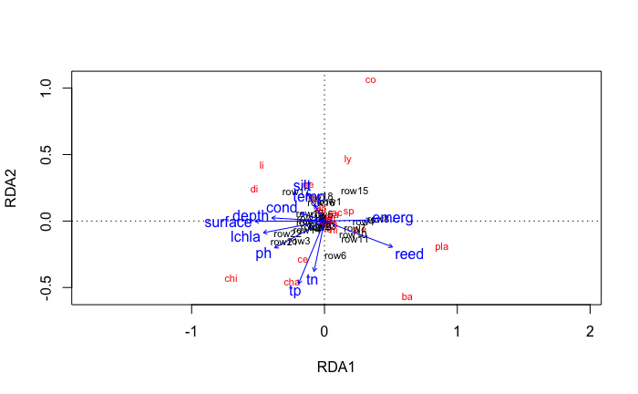

```r
# ideally would like ponds represented by symbols, a different one for each management category
ordiplot(lemmens2.rda,scaling=1,type="text")
```

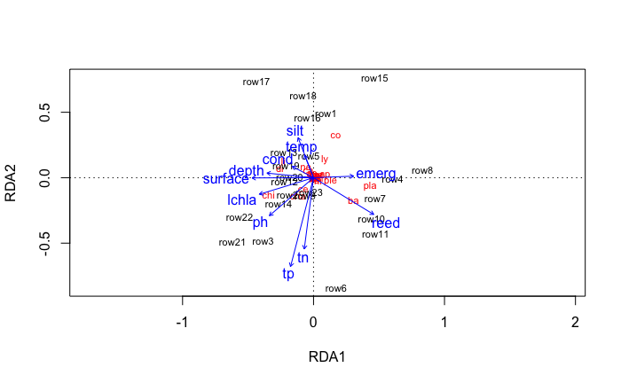

```r
ordiplot(lemmens2.rda,scaling=2,type="text")
```

## Do CCA without hellinger transform for comparison

## Management first

```r
lemmens1.cca <- cca(lemminvert1~manag, scale=FALSE, data=lemmenv)
summary(lemmens1.cca)
```

```
Call:
cca(formula = lemminvert1 ~ manag, data = lemmenv, scale = FALSE)

Partitioning of scaled Chi-square:
                Inertia Proportion
Total         1.3064388  1.0000000
Constrained   0.3205724  0.2453788
Unconstrained 0.9858664  0.7546212

Eigenvalues, and their contribution to the scaled Chi-square

Importance of components:
                           CCA1       CCA2       CCA3       CA1       CA2       CA3        CA4        CA5        CA6        CA7        CA8        CA9       CA10       CA11
Eigenvalue            0.2126994 0.06529970 0.04257331 0.1979512 0.1421607 0.1361162 0.11519732 0.09440232 0.07995911 0.07312735 0.03626965 0.02754670 0.02111008 0.01986766
Proportion Explained  0.1628085 0.04998298 0.03258730 0.1515197 0.1088154 0.1041888 0.08817659 0.07225928 0.06120387 0.05597457 0.02776223 0.02108534 0.01615849 0.01520750
Cumulative Proportion 0.1628085 0.21279152 0.24537882 0.3968985 0.5057139 0.6099027 0.69807926 0.77033853 0.83154241 0.88751698 0.91527920 0.93636454 0.95252303 0.96773053
                            CA12        CA13        CA14        CA15        CA16        CA17         CA18         CA19
Eigenvalue            0.01527327 0.009234612 0.005370932 0.004777111 0.003991910 0.002447783 0.0007410925 0.0003213826
Proportion Explained  0.01169077 0.007068538 0.004111124 0.003656590 0.003055566 0.001873630 0.0005672616 0.0002459989
Cumulative Proportion 0.97942129 0.986489831 0.990600954 0.994257544 0.997313110 0.999186739 0.9997540011 1.0000000000

Accumulated constrained eigenvalues
Importance of components:
                           CCA1      CCA2       CCA3
Eigenvalue            0.2126994 0.0652997 0.04257331
Proportion Explained  0.6634988 0.2036972 0.13280404
Cumulative Proportion 0.6634988 0.8671960 1.00000000

Scaling 2 for species and site scores
* Species are scaled proportional to eigenvalues
* Sites are unscaled: weighted dispersion equal on all dimensions


Species scores

           CCA1         CCA2        CCA3         CA1         CA2         CA3
ca   0.36061292 -1.131172976  0.51530227  0.60561239  0.60531036  0.58967975
ba  -0.29444809  0.097678281 -0.18353776  0.18655528  0.40371880 -0.28918679
ac  -0.35189406 -0.417577456  0.44862988  0.50056711  2.20502272 -1.70819407
ly  -0.41935632 -0.184101414  0.35127980 -0.07674487 -0.15897892 -0.15247518
```

[output cut: 83 more lines]

```
Biplot scores for constraining variables

             CCA1       CCA2        CCA3 CA1 CA2 CA3
manag1 -0.2275361 -0.9733484 -0.02863793   0   0   0
manag2 -0.9874600 -0.1105667  0.11268457   0   0   0
manag3 -0.2058289 -0.3455633 -0.91554379   0   0   0


Centroids for factor constraints

              CCA1       CCA2       CCA3 CA1 CA2 CA3
managnm  1.1144852 -2.5396085  0.9199048   0   0   0
managnf -0.7611162  0.1746173  0.3171113   0   0   0
managyf  0.5174422 -0.0596621 -1.8786727   0   0   0
managli  2.1567903  1.7283528  1.0714464   0   0   0
```

```r
RsquareAdj(lemmens1.cca)
```

```
$r.squared
[1] 0.245378816

$adj.r.squared
[1] 0.1321851352
```

```r
coef(lemmens1.cca)
```

```
                CCA1          CCA2          CCA3
manag1  0.3575848454 -2.3655333724  0.8124573618
manag2 -1.5180165584  0.3486923830  0.2096638546
manag3 -0.2394581823  0.1144130236 -1.9861201688
```

```r
anova.cca(lemmens1.cca, permutations=1000)
```

```
Permutation test for cca under reduced model
Permutation: free
Number of permutations: 1000

Model: cca(formula = lemminvert1 ~ manag, data = lemmenv, scale = FALSE)
         Df  ChiSquare      F   Pr(>F)
Model     3 0.32057241 2.0594 0.001998 **
Residual 19 0.98586641
---
Signif. codes:  0 ‘***’ 0.001 ‘**’ 0.01 ‘*’ 0.05 ‘.’ 0.1 ‘ ’ 1
```

```r
anova.cca(lemmens1.cca, permutations=1000, by="margin")
```

```
Permutation test for cca under reduced model
Marginal effects of terms
Permutation: free
Number of permutations: 1000

Model: cca(formula = lemminvert1 ~ manag, data = lemmenv, scale = FALSE)
         Df  ChiSquare      F   Pr(>F)
manag     3 0.32057241 2.0594 0.001998 **
Residual 19 0.98586641
---
Signif. codes:  0 ‘***’ 0.001 ‘**’ 0.01 ‘*’ 0.05 ‘.’ 0.1 ‘ ’ 1
```

```r
anova.cca(lemmens1.cca, permutations=1000, by="axis")
```

```
Permutation test for cca under reduced model
Forward tests for axes
Permutation: free
Number of permutations: 1000

Model: cca(formula = lemminvert1 ~ manag, data = lemmenv, scale = FALSE)
         Df  ChiSquare       F   Pr(>F)
CCA1      1 0.21269940 4.09923 0.001998 **
CCA2      1 0.06529970 1.25848 0.491508
CCA3      1 0.04257331 0.82049 0.635365
Residual 19 0.98586641
---
Signif. codes:  0 ‘***’ 0.001 ‘**’ 0.01 ‘*’ 0.05 ‘.’ 0.1 ‘ ’ 1
```

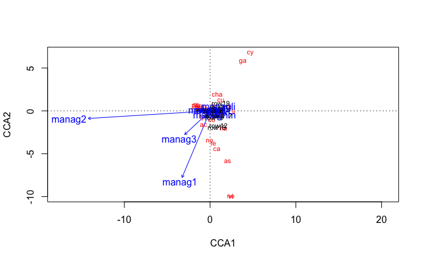

```r
ordiplot(lemmens1.cca,scaling=1,type="text")
```

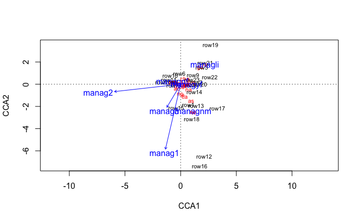

```r
ordiplot(lemmens1.cca,scaling=2,type="text")
```

### Now env variables

```r
lemmens2.cca <- cca(lemminvert1~depth+silt+ph+temp+surface+cond+lchla+tn+tp+reed+emerg, scale=FALSE, data=lemmenv)
summary(lemmens2.cca)
```

```
Call:
cca(formula = lemminvert1 ~ depth + silt + ph + temp + surface +      cond + lchla + tn + tp + reed + emerg, data = lemmenv, scale = FALSE)

Partitioning of scaled Chi-square:
                Inertia Proportion
Total         1.3064388   1.000000
Constrained   0.8476070   0.648792
Unconstrained 0.4588318   0.351208

Eigenvalues, and their contribution to the scaled Chi-square

Importance of components:
                           CCA1       CCA2       CCA3      CCA4       CCA5       CCA6       CCA7       CCA8        CCA9       CCA10       CCA11        CA1        CA2        CA3
Eigenvalue            0.3089047 0.12250474 0.11334823 0.1025672 0.06607109 0.04594123 0.04188759 0.02394964 0.009575194 0.007580523 0.005276912 0.13042347 0.08363283 0.07065464
Proportion Explained  0.2364479 0.09376998 0.08676123 0.0785090 0.05057343 0.03516524 0.03206242 0.01833200 0.007329233 0.005802433 0.004039157 0.09983129 0.06401588 0.05408186
Cumulative Proportion 0.2364479 0.33021783 0.41697906 0.4954881 0.54606149 0.58122672 0.61328914 0.63162114 0.638950376 0.644752809 0.648791966 0.74862325 0.81263913 0.86672099
                             CA4        CA5        CA6        CA7        CA8         CA9        CA10        CA11
Eigenvalue            0.05466948 0.03496095 0.02269653 0.02121667 0.01874746 0.009480517 0.008061064 0.004288213
Proportion Explained  0.04184618 0.02676049 0.01737282 0.01624008 0.01435005 0.007256763 0.006170258 0.003282368
Cumulative Proportion 0.90856718 0.93532767 0.95270049 0.96894057 0.98329061 0.990547374 0.996717632 1.000000000

Accumulated constrained eigenvalues
Importance of components:
                           CCA1      CCA2      CCA3      CCA4       CCA5       CCA6       CCA7       CCA8        CCA9       CCA10       CCA11
Eigenvalue            0.3089047 0.1225047 0.1133482 0.1025672 0.06607109 0.04594123 0.04188759 0.02394964 0.009575194 0.007580523 0.005276912
Proportion Explained  0.3644433 0.1445301 0.1337273 0.1210080 0.07795015 0.05420110 0.04941864 0.02825560 0.011296737 0.008943441 0.006225658
Cumulative Proportion 0.3644433 0.5089734 0.6427007 0.7637087 0.84165883 0.89585993 0.94527857 0.97353416 0.984830901 0.993774342 1.000000000

Scaling 2 for species and site scores
* Species are scaled proportional to eigenvalues
* Sites are unscaled: weighted dispersion equal on all dimensions


Species scores

           CCA1         CCA2        CCA3         CCA4        CCA5         CCA6
ca   0.30536887  0.140131065 -0.05655802 -0.396122011  0.58276019  0.607248294
ba  -0.46323941  0.034351374  0.35484723 -0.002699521  0.21885460 -0.044486949
ac  -0.46478426  2.139398779  1.38041260 -1.224250980 -0.31408540  1.640353187
ly  -0.42224621 -0.284374489 -0.16832082  0.149183242  0.23432899 -0.066777681
```

[output cut: 82 more lines]

```

Biplot scores for constraining variables

              CCA1          CCA2        CCA3         CCA4         CCA5        CCA6
depth    0.5847473  0.4528700006  0.16780852  0.244204814  0.021130518  0.11470024
silt     0.2743782  0.2345331295 -0.18236078 -0.015834857 -0.098934164  0.65632974
ph       0.5539206 -0.1731813544  0.28947608  0.006991876  0.135468755  0.14013068
temp    -0.2076255 -0.1878390262 -0.23448591  0.341862845  0.162822339 -0.25863042
surface  0.7200449  0.2449314478 -0.08191369  0.157465584 -0.506655663 -0.03742950
cond     0.4488143  0.3592523114 -0.35557402  0.265889976  0.001756454 -0.30807371
lchla    0.1768793 -0.2691333677  0.36603291  0.063248397  0.594158324 -0.28948295
tn       0.1194490 -0.0007478341  0.33111470  0.336699819 -0.569024410 -0.38077220
tp       0.3366933 -0.2685092789  0.38631273  0.175936665 -0.337182484 -0.35070627
reed    -0.5671781 -0.0345491230  0.21864744  0.342564356  0.009118245 -0.09680661
emerg   -0.2022890  0.6652325154  0.01904904 -0.280165593 -0.432606120 -0.04791727
```

```r
RsquareAdj(lemmens2.cca)
```

```
$r.squared
[1] 0.6487919661

$adj.r.squared
[1] 0.3221586836
```

```r
coef(lemmens2.cca)
```

```
                   CCA1           CCA2          CCA3           CCA4           CCA5          CCA6           CCA7           CCA8           CCA9         CCA10          CCA11
depth   -0.066539712236  0.96280842662  0.5406505133  1.28833478814  0.26666886924  0.1726202332  0.65796573889 -0.82802081822  0.10827547138 -0.4476052213  0.65212933505
silt     0.161762328239 -0.09135611086  0.1293435591  0.53354734063  0.01880639300  0.9098977223 -0.55971463694  0.70170696899  1.03840220411  0.4336179958 -0.84602093795
ph      -0.006636006879 -0.13599469934  0.2518456285 -0.62046343044  0.01350561394  0.5663009265 -0.29253717887  0.61713638219 -0.71714846972 -0.7727238411 -0.60889193713
temp    -0.237453825454  0.27614949100 -0.3238749038  1.65888130251 -0.23938301589  0.2137030431  1.02763770746  0.08488582728  0.17138584417 -1.0270382846  0.39028411390
surface  0.895432275786 -0.51280484309 -0.4397461854 -0.03188881466 -0.64903021311  0.3919411180  0.45754331613  0.44561621484 -0.60224107673  0.5666761109  0.87113888883
cond     0.035730783849  0.20816466461 -0.6466292115 -0.52081629247  0.50279967795 -0.7668486376 -1.00037817595  0.41863433290  0.10385365451  0.1532509210 -0.74056658365
lchla    1.081074937017 -0.11095517842  0.9026346352 -0.66509686361  1.17881979584 -0.6790256069 -0.13046692996  0.79359814527  0.53223356611  1.4607412409 -0.47059185592
tn       0.110531773475 -0.37589156172  0.4497828844 -0.35433812223 -0.29211684378 -0.3567024003 -0.47722491534 -0.50276715774 -0.04089715496  0.9182710536 -1.98736568881
tp      -0.229639704436  0.08244039408  0.4463635874  0.87161108436 -0.42254809523 -0.4654969432  0.06120385482  0.18854091789  0.96367131608 -0.8642624381  0.97810142298
reed    -0.534953402005  0.04291148566  0.3509904173  0.58057579084  0.02778363371  0.6203607959 -0.52329288974  0.86236588574 -0.46441902411  0.1737193114  0.40880133802
emerg   -0.308348442016  1.12860404740  0.5194305421 -0.45281560189 -0.24060238981 -0.2116380072  0.21862037347  0.66281604122  0.14471449531 -0.6056461956  0.01218897821
```

```r
anova.cca(lemmens2.cca, permutations=1000)
```

```
Permutation test for cca under reduced model
Permutation: free
Number of permutations: 1000

Model: cca(formula = lemminvert1 ~ depth + silt + ph + temp + surface + cond + lchla + tn + tp + reed + emerg, data = lemmenv, scale = FALSE)
         Df  ChiSquare       F   Pr(>F)
Model    11 0.84760701 1.84732 0.000999 ***
Residual 11 0.45883181
---
Signif. codes:  0 ‘***’ 0.001 ‘**’ 0.01 ‘*’ 0.05 ‘.’ 0.1 ‘ ’ 1
```

```r
anova.cca(lemmens2.cca, permutations=1000, by="margin")
```

```
Permutation test for cca under reduced model
Marginal effects of terms
Permutation: free
Number of permutations: 1000

Model: cca(formula = lemminvert1 ~ depth + silt + ph + temp + surface + cond + lchla + tn + tp + reed + emerg, data = lemmenv, scale = FALSE)
         Df  ChiSquare       F   Pr(>F)
depth     1 0.07653476 1.83484 0.047952 *
silt      1 0.03003632 0.72009 0.635365
ph        1 0.03209059 0.76934 0.588412
temp      1 0.07052392 1.69074 0.043956 *
surface   1 0.09776895 2.34391 0.006993 **
cond      1 0.05217511 1.25084 0.191808
lchla     1 0.08569971 2.05456 0.029970 *
tn        1 0.01863280 0.44670 0.881119
tp        1 0.03916227 0.93887 0.419580
reed      1 0.07305856 1.75150 0.057942 .
emerg     1 0.09159059 2.19579 0.009990 **
Residual 11 0.45883181
---
Signif. codes:  0 ‘***’ 0.001 ‘**’ 0.01 ‘*’ 0.05 ‘.’ 0.1 ‘ ’ 1
```

```r
anova.cca(lemmens2.cca, permutations=1000, by="axis")
```

```
Permutation test for cca under reduced model
Forward tests for axes
Permutation: free
Number of permutations: 1000

Model: cca(formula = lemminvert1 ~ depth + silt + ph + temp + surface + cond + lchla + tn + tp + reed + emerg, data = lemmenv, scale = FALSE)
         Df  ChiSquare       F   Pr(>F)
CCA1      1 0.30890465 7.40566 0.000999 ***
CCA2      1 0.12250474 2.93692 0.231768
CCA3      1 0.11334823 2.71740 0.444555
CCA4      1 0.10256720 2.45894 0.562438
CCA5      1 0.06607109 1.58398 0.926074
CCA6      1 0.04594123 1.10139 0.993007
CCA7      1 0.04188759 1.00421 0.989011
CCA8      1 0.02394964 0.57417 1.000000
CCA9      1 0.00957519 0.22955 1.000000
CCA10     1 0.00758052 0.18173 1.000000
CCA11     1 0.00527691 0.12651 1.000000
Residual 11 0.45883181
---
Signif. codes:  0 ‘***’ 0.001 ‘**’ 0.01 ‘*’ 0.05 ‘.’ 0.1 ‘ ’ 1
```

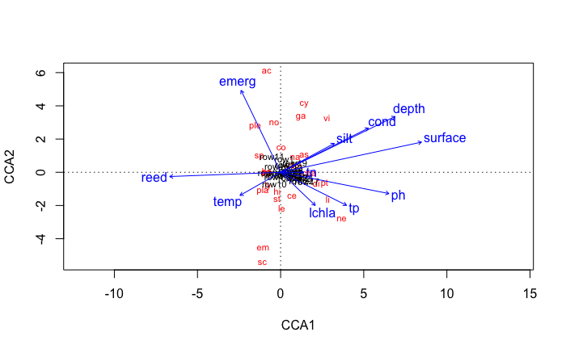

```r
# ideally would like ponds represented by symbols, a different one for each management category
ordiplot(lemmens2.cca,scaling=1,type="text")
```

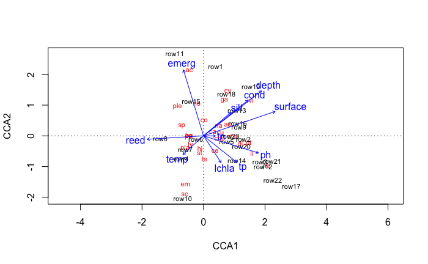

```r
ordiplot(lemmens2.cca,scaling=2,type="text")
```

## Nice graphics

Plots used for QK use the ggplot classic theme, with some tweaks. Tweaks are consolidated into theme_QK; use this theme for figures and tweak the theme to avoid repetitive code changes.

```r
source("../R/appearance.R")
```

```r
library(ggvegan)
p1<-autoplot(lemmens1.rda)
p2<-autoplot(lemmens2.rda)
p3<-autoplot(lemmens1.cca)
p4<-autoplot(lemmens2.cca)
l1rt<-fortify(lemmens1.rda)
l1rt$Label <- l1rt$Label %>%
  str_replace_all("managnm", "nm") %>%
str_replace_all("managli", "li") %>%
str_replace_all("managnf", "nf") %>%
str_replace_all("managyf", "yf")
l2rt<-fortify(lemmens2.rda)
l1ct<-fortify(lemmens1.cca)
l1ct$Label <- l1ct$Label %>%
  str_replace_all("managnm", "nm") %>%
str_replace_all("managli", "li") %>%
str_replace_all("managnf", "nf") %>%
str_replace_all("managyf", "yf")
l2ct<-fortify(lemmens2.cca)
p5<-p1+p2+p3+p4
```

|  | t | l | b | r |
| --- | --- | --- | --- | --- |
| 1: | 1 | 1 | 1 | 1 |
| 2: | 2 | 1 | 2 | 1 |
| 3: | 1 | 2 | 1 | 2 |
| 4: | 2 | 2 | 2 | 2 |

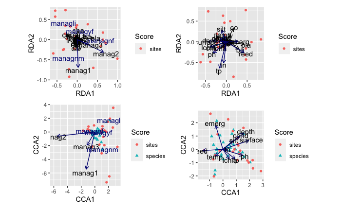

```r
p5
```

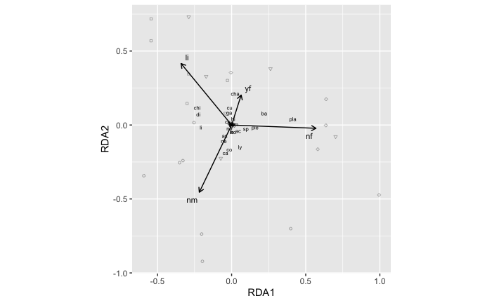

```r
library(ggrepel)
br=c("nm","li","nf","yf")  #Set order of groups; define as object to avoid repeated code
la=c("None", "Light", "No fish", "Young fish")  #Set legend text
p1a<-ggplot()+
  geom_point(aes(x=RDA1,y=RDA2, shape=lemminvert$manag), color=sc, data=filter(l1rt, Score=="sites"),
             alpha=0.7, size=1)+
  scale_shape_manual(values=c(21,22,23,25),
                     name="Management",
                     breaks=br,
                     labels=la
                     )+
  geom_text(aes(x=RDA1,y=RDA2, label=Label), size=2, data=filter(l1rt, Score=="species"),
                  )+
  geom_segment(aes(x=0,y=0,xend=RDA1,yend=RDA2), arrow=arrow(length=unit(0.2,"cm")),
               data=filter(l1rt, Score=="centroids"))+
  geom_text_repel(aes(x=RDA1,y=RDA2, label=Label), size=3, data=filter(l1rt, Score=="centroids"),
                  max.overlaps=Inf)+
                 coord_fixed()+
  theme(legend.position="none")
p1a
```

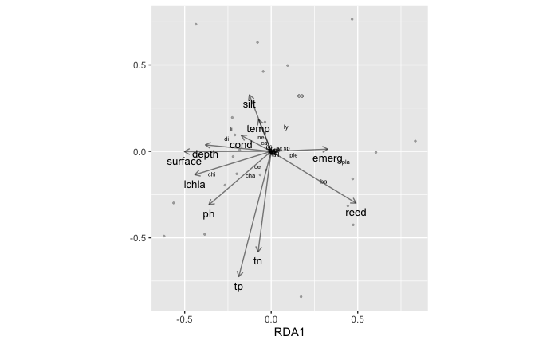

```r
p2a<-ggplot()+
  geom_point(aes(x=RDA1,y=RDA2, ), data=filter(l2rt, Score=="sites"), alpha=0.7, color=sc, size=0.5)+
  geom_text(aes(x=RDA1,y=RDA2, label=Label), size=2, data=filter(l2rt, Score=="species"),
                  )+
  geom_segment(aes(x=0,y=0,xend=RDA1,yend=RDA2), alpha=0.5, arrow=arrow(length=unit(0.2,"cm")),
               data=filter(l2rt, Score=="biplot"))+
  geom_text(aes(x=RDA1,y=RDA2, label=Label), nudge_y=-0.05,color=lc, size=3.5, data=filter(l2rt, Score=="biplot"),
                  )+
  labs(y=NULL)+
                 coord_fixed()
p2a
```

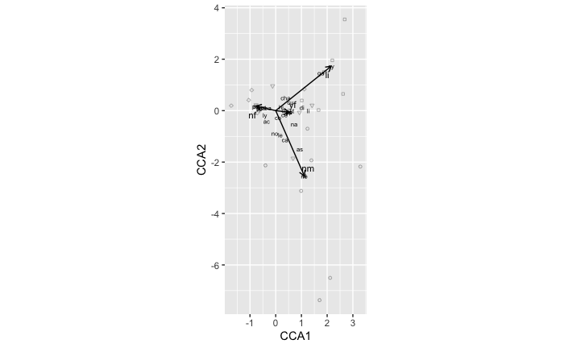

```r
p3a<-ggplot()+
  geom_point(aes(x=CCA1,y=CCA2, shape=lemminvert$manag), color= sc, data=filter(l1ct, Score=="sites"), alpha=0.7, size=1)+
  scale_shape_manual(values=c(21,22,23,25),
                     name="Management",
                     breaks=br,
                     labels=la
                     )+
  geom_text(aes(x=CCA1,y=CCA2, label=Label), size=2, data=filter(l1ct, Score=="species"),
                  )+
  geom_segment(aes(x=0,y=0,xend=CCA1,yend=CCA2), arrow=arrow(length=unit(0.2,"cm")),
               data=filter(l1ct, Score=="centroids"))+
  geom_text_repel(aes(x=CCA1,y=CCA2, label=Label), size=3, data=filter(l1ct, Score=="centroids"),
                  max.overlaps=Inf)+
                 coord_fixed()+
  theme(legend.position="none")
p3a
```

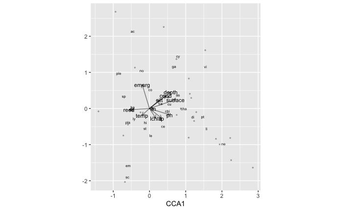

```r
p4a<-ggplot()+
  geom_point(aes(x=CCA1,y=CCA2, ), data=filter(l2ct, Score=="sites"), alpha=0.7, color=sc, size=0.5)+
  geom_text(aes(x=CCA1,y=CCA2, label=Label), size=2, data=filter(l2ct, Score=="species"),
                  )+
  geom_segment(aes(x=0,y=0,xend=CCA1,yend=CCA2), alpha=0.5, arrow=arrow(length=unit(0.2,"cm")),
               data=filter(l2ct, Score=="biplot"))+
  geom_text(aes(x=CCA1,y=CCA2, label=Label), color=lc, size=3, data=filter(l2ct, Score=="biplot"),
                  )+
  labs(y=NULL)+
                 coord_fixed()
p4a
```

Combine panels

```r
p5<-p1a+p2a+p3a+p4a
```

|  | t | l | b | r |
| --- | --- | --- | --- | --- |
| 1: | 1 | 1 | 1 | 1 |
| 2: | 2 | 1 | 2 | 1 |
| 3: | 1 | 2 | 1 | 2 |
| 4: | 2 | 2 | 2 | 2 |

```r
p5<-p5&theme_qk()+theme(legend.position="none")
```

|  | t | l | b | r |
| --- | --- | --- | --- | --- |
| 1: | 1 | 1 | 1 | 1 |
| 2: | 2 | 1 | 2 | 1 |
| 3: | 1 | 2 | 1 | 2 |
| 4: | 2 | 2 | 2 | 2 |

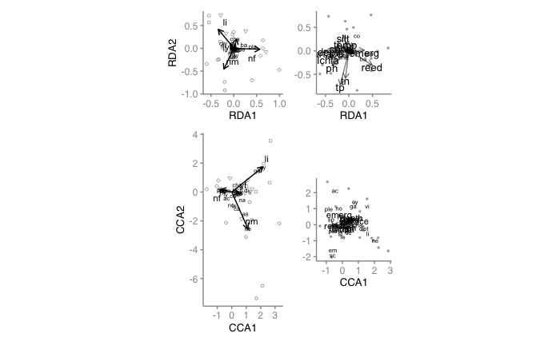

```r
p5
```

```r
#ggsave("../Illustrator/QK F15_05.pdf",plot = p5, height = phh,width = pww, units='cm')
```

Colour version of LH panels

```r
p1b<-ggplot()+
  geom_point(aes(x=RDA1,y=RDA2, color=lemminvert$manag), data=filter(l1rt, Score=="sites"),
             alpha=0.7, size=1)+
  scale_color_viridis_d(
                     name="Management",
                     breaks=br,
                     labels=la
                     )+
  geom_text(aes(x=RDA1,y=RDA2, label=Label), size=2, data=filter(l1rt, Score=="species"),
                  )+
  geom_segment(aes(x=0,y=0,xend=RDA1,yend=RDA2), arrow=arrow(length=unit(0.2,"cm")),
               data=filter(l1rt, Score=="centroids"))+
  geom_text_repel(aes(x=RDA1,y=RDA2, label=Label), size=3, data=filter(l1rt, Score=="centroids"),
                  max.overlaps=Inf)+
                 coord_fixed()+
  theme(legend.position="none")
p3b<-ggplot()+
  geom_point(aes(x=CCA1,y=CCA2, color=lemminvert$manag), data=filter(l1ct, Score=="sites"), alpha=0.7, size=1)+
  scale_color_viridis_d(
                     breaks=br,
                     labels=la
                     )+
  geom_text(aes(x=CCA1,y=CCA2, label=Label), size=2, data=filter(l1ct, Score=="species"),
                  )+
  geom_segment(aes(x=0,y=0,xend=CCA1,yend=CCA2), arrow=arrow(length=unit(0.2,"cm")),
               data=filter(l1ct, Score=="centroids"))+
  geom_text_repel(aes(x=CCA1,y=CCA2, label=Label), size=3, data=filter(l1ct, Score=="centroids"),
                  max.overlaps=Inf)+
                 coord_fixed()+
  theme(legend.position="none")
```

```r
p5a<-p1b+p2a+p3b+p4a
```

|  | t | l | b | r |
| --- | --- | --- | --- | --- |
| 1: | 1 | 1 | 1 | 1 |
| 2: | 2 | 1 | 2 | 1 |
| 3: | 1 | 2 | 1 | 2 |
| 4: | 2 | 2 | 2 | 2 |

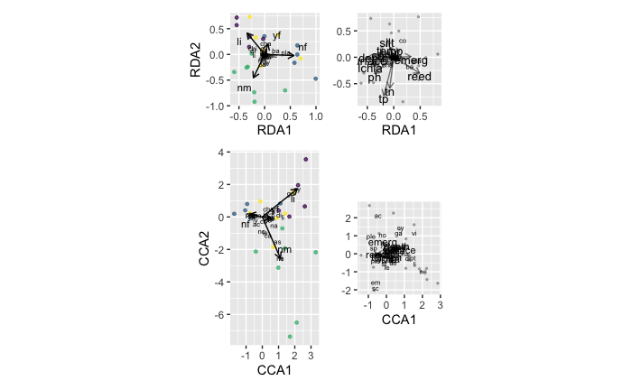

```r
p5a
```

```r
p5a<-p5a&theme_qk()+theme(legend.position="none")
```

|  | t | l | b | r |
| --- | --- | --- | --- | --- |
| 1: | 1 | 1 | 1 | 1 |
| 2: | 2 | 1 | 2 | 1 |
| 3: | 1 | 2 | 1 | 2 |
| 4: | 2 | 2 | 2 | 2 |

```r
#ggsave("QK F15_05c.pdf",plot = p5a, height = phh,width = pww, units='cm')
```